# EasyVisa_ML_model

### Problem Defintion

Organizations in the United States rely heavily on skilled professionals to remain competitive in a rapidly growing economy. Due to increasing labor demand, companies often hire foreign workers when qualified domestic workers are not available. However, evaluating and processing a large number of visa applications every year has become time-consuming and complex.

The Office of Foreign Labor Certification (OFLC) reviews these applications to ensure that hiring foreign workers does not negatively affect U.S. workers’ wages or working conditions. With the rising number of applications, manually reviewing each case becomes inefficient and may delay decision-making.

Therefore, there is a need for a data-driven approach that can help predict whether a visa application is likely to be certified or denied. A machine learning model can assist in identifying patterns in historical data and support faster, more consistent decision-making.

### Objective

The main objective of this project is to build a classification model that can predict the outcome of a visa application (Certified or Denied) based on the applicant’s and employer’s information.

Specifically, the project aims to:

1. Analyze historical visa application data.
2. Identify the key factors influencing visa approval decisions.
3. Build and compare multiple classification models.
4. Handle class imbalance effectively using sampling techniques.
5. Tune the best-performing models to improve predictive performance.
6. Recommend the most suitable model for assisting the visa approval process.

The final goal is to support OFLC and EasyVisa in shortlisting applications with a higher probability of approval, thereby improving efficiency and reducing manual workload.

### Data Description

The dataset contains information related to visa applications, including details about the employee and the employer. Each row represents one visa application. The important features in the dataset are described below:

1. **case_id:** Unique identification number for each visa application.
2. **continent:** Continent from which the employee belongs.
3. **education_of_employee:** Educational qualification of the applicant.
4. **has_job_experience:** Indicates whether the applicant has prior work experience (Yes/No).
5. **requires_job_training:** Indicates whether the job requires additional training (Yes/No).
6. **no_of_employees:** Total number of employees in the employer’s company.
7. **yr_of_estab:** Year in which the employer’s company was established.
8. **region_of_employment:** U.S. region where the employee is intended to work.
9. **prevailing_wage:** Standard wage for similar jobs in the area of employment.
10. **unit_of_wage:** Wage unit (Hourly, Weekly, Monthly, or Yearly).
11. **full_time_position:** Indicates whether the job is full-time or part-time.
12. **case_status:** Target variable indicating whether the visa was Certified or Denied.

The target variable for this project is case_status, which will be predicted using classification models.

### Importing necessary libraries

```python
import pandas as pd
import numpy as np
import matplotlib.pyplot as plt
import seaborn as sns
```

### Loading Dataset

```python
#importing csv dataset file into a dataframe
import pandas as pd
df=pd.read_csv("/content/EasyVisa.csv")
df
```

|  | case_id | continent | education_of_employee | has_job_experience | requires_job_training | no_of_employees | yr_of_estab | region_of_employment | prevailing_wage | unit_of_wage | full_time_position | case_status |
| --- | --- | --- | --- | --- | --- | --- | --- | --- | --- | --- | --- | --- |
| 0 | EZYV01 | Asia | High School | N | N | 14513 | 2007 | West | 592.2029 | Hour | Y | Denied |
| 1 | EZYV02 | Asia | Master's | Y | N | 2412 | 2002 | Northeast | 83425.6500 | Year | Y | Certified |
| 2 | EZYV03 | Asia | Bachelor's | N | Y | 44444 | 2008 | West | 122996.8600 | Year | Y | Denied |
| 3 | EZYV04 | Asia | Bachelor's | N | N | 98 | 1897 | West | 83434.0300 | Year | Y | Denied |
| 4 | EZYV05 | Africa | Master's | Y | N | 1082 | 2005 | South | 149907.3900 | Year | Y | Certified |
| ... | ... | ... | ... | ... | ... | ... | ... | ... | ... | ... | ... | ... |
| 25475 | EZYV25476 | Asia | Bachelor's | Y | Y | 2601 | 2008 | South | 77092.5700 | Year | Y | Certified |
| 25476 | EZYV25477 | Asia | High School | Y | N | 3274 | 2006 | Northeast | 279174.7900 | Year | Y | Certified |
| 25477 | EZYV25478 | Asia | Master's | Y | N | 1121 | 1910 | South | 146298.8500 | Year | N | Certified |
| 25478 | EZYV25479 | Asia | Master's | Y | Y | 1918 | 1887 | West | 86154.7700 | Year | Y | Certified |
| 25479 | EZYV25480 | Asia | Bachelor's | Y | N | 3195 | 1960 | Midwest | 70876.9100 | Year | Y | Certified |

25480 rows × 12 columns

```python
# View first 5 rows
df.head()
```

|  | case_id | continent | education_of_employee | has_job_experience | requires_job_training | no_of_employees | yr_of_estab | region_of_employment | prevailing_wage | unit_of_wage | full_time_position | case_status |
| --- | --- | --- | --- | --- | --- | --- | --- | --- | --- | --- | --- | --- |
| 0 | EZYV01 | Asia | High School | N | N | 14513 | 2007 | West | 592.2029 | Hour | Y | Denied |
| 1 | EZYV02 | Asia | Master's | Y | N | 2412 | 2002 | Northeast | 83425.6500 | Year | Y | Certified |
| 2 | EZYV03 | Asia | Bachelor's | N | Y | 44444 | 2008 | West | 122996.8600 | Year | Y | Denied |
| 3 | EZYV04 | Asia | Bachelor's | N | N | 98 | 1897 | West | 83434.0300 | Year | Y | Denied |
| 4 | EZYV05 | Africa | Master's | Y | N | 1082 | 2005 | South | 149907.3900 | Year | Y | Certified |

```python
#view last 5 rows
df.tail()
```

|  | case_id | continent | education_of_employee | has_job_experience | requires_job_training | no_of_employees | yr_of_estab | region_of_employment | prevailing_wage | unit_of_wage | full_time_position | case_status |
| --- | --- | --- | --- | --- | --- | --- | --- | --- | --- | --- | --- | --- |
| 25475 | EZYV25476 | Asia | Bachelor's | Y | Y | 2601 | 2008 | South | 77092.57 | Year | Y | Certified |
| 25476 | EZYV25477 | Asia | High School | Y | N | 3274 | 2006 | Northeast | 279174.79 | Year | Y | Certified |
| 25477 | EZYV25478 | Asia | Master's | Y | N | 1121 | 1910 | South | 146298.85 | Year | N | Certified |
| 25478 | EZYV25479 | Asia | Master's | Y | Y | 1918 | 1887 | West | 86154.77 | Year | Y | Certified |
| 25479 | EZYV25480 | Asia | Bachelor's | Y | N | 3195 | 1960 | Midwest | 70876.91 | Year | Y | Certified |

```python
# Shape of data
df.shape
```

```
(25480, 12)
```

Dataframe has 25480 rows and 12 columns.

```python
df.columns
```

```
Index(['case_id', 'continent', 'education_of_employee', 'has_job_experience',
       'requires_job_training', 'no_of_employees', 'yr_of_estab',
       'region_of_employment', 'prevailing_wage', 'unit_of_wage',
       'full_time_position', 'case_status'],
      dtype='object')
```

It displays all the names of the columns present in the dataframe.

```python
# Display basic information about the dataset
df.info()
```

```
<class 'pandas.core.frame.DataFrame'>
RangeIndex: 25480 entries, 0 to 25479
Data columns (total 12 columns):
 #   Column                 Non-Null Count  Dtype
---  ------                 --------------  -----
 0   case_id                25480 non-null  object
 1   continent              25480 non-null  object
 2   education_of_employee  25480 non-null  object
 3   has_job_experience     25480 non-null  object
 4   requires_job_training  25480 non-null  object
 5   no_of_employees        25480 non-null  int64
 6   yr_of_estab            25480 non-null  int64
 7   region_of_employment   25480 non-null  object
 8   prevailing_wage        25480 non-null  float64
 9   unit_of_wage           25480 non-null  object
 10  full_time_position     25480 non-null  object
 11  case_status            25480 non-null  object
dtypes: float64(1), int64(2), object(9)
memory usage: 2.3+ MB
```

Key Observations:

1. Dataset has 25,480 rows and 12 columns.
2. No missing values present.
3. 9 categorical features and 3 numerical features.
4. case_status is the target variable (binary classification).
5. case_id is an identifier and should be removed before modeling.
6. Memory usage is low (2.3 MB), so computation will be efficient.

```python
# Statistical summary
df.describe()
```

|  | no_of_employees | yr_of_estab | prevailing_wage |
| --- | --- | --- | --- |
| count | 25480.000000 | 25480.000000 | 25480.000000 |
| mean | 5667.043210 | 1979.409929 | 74455.814592 |
| std | 22877.928848 | 42.366929 | 52815.942327 |
| min | -26.000000 | 1800.000000 | 2.136700 |
| 25% | 1022.000000 | 1976.000000 | 34015.480000 |
| 50% | 2109.000000 | 1997.000000 | 70308.210000 |
| 75% | 3504.000000 | 2005.000000 | 107735.512500 |
| max | 602069.000000 | 2016.000000 | 319210.270000 |

Key Observations

1. no_of_employees has negative values : data error, needs treatment.
2. Very high maximum (602,069) :strong outliers present.
3. yr_of_estab ranges from 1800–2016 : values look reasonable.
4. prevailing_wage has high variation : possible wage outliers.
5. Scaling may be needed due to large value differences.

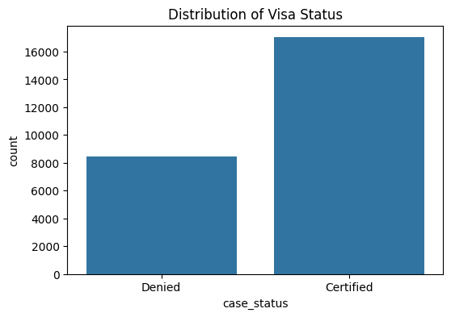

| case_status | proportion |
| --- | --- |
| Certified | 66.789639 |
| Denied | 33.210361 |

**dtype:** float64

```python
#Target Variable Distribution
plt.figure(figsize=(6,4))
sns.countplot(x="case_status", data=df)
plt.title("Distribution of Visa Status")
plt.show()

# Percentage distribution
df["case_status"].value_counts(normalize=True)*100
```

Observations:

1. The number of Certified cases is significantly higher than Denied cases.
2. Approximately two-thirds of the applications are certified.
3. The dataset shows a class imbalance, with Certified being the majority class.
4. This imbalance may bias the model toward predicting Certified more often.

### Univariate Analysis

#### Categorical Variables

```python
# Selecting all categorical (object type) columns from the dataset
cat_cols = df.select_dtypes(include="object").columns
cat_cols
```

```
Index(['case_id', 'continent', 'education_of_employee', 'has_job_experience',
       'requires_job_training', 'region_of_employment', 'unit_of_wage',
       'full_time_position', 'case_status'],
      dtype='object')
```

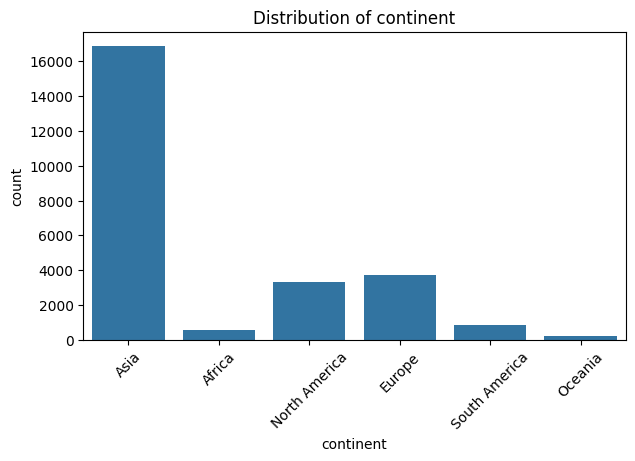

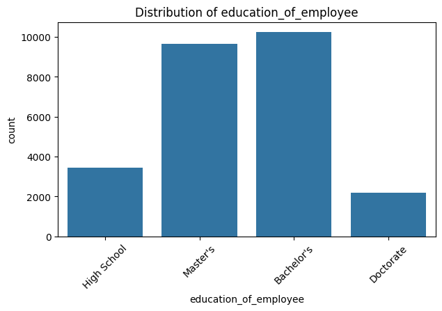

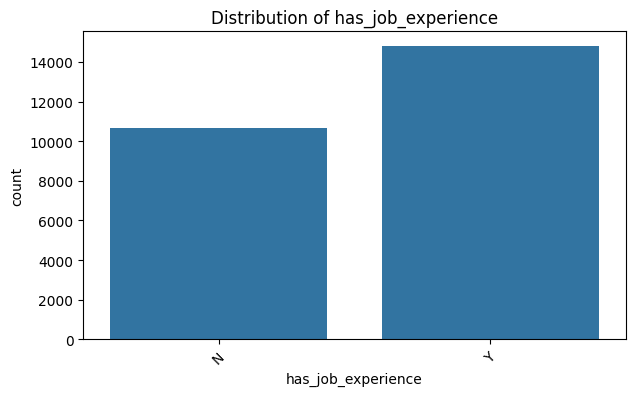

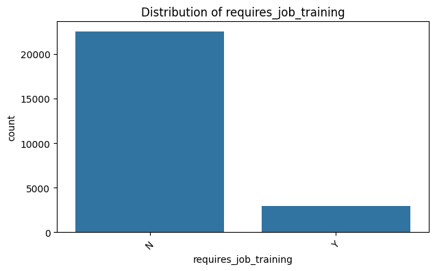

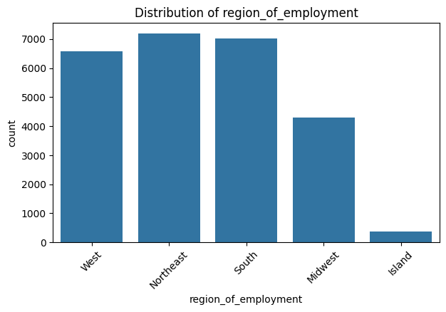

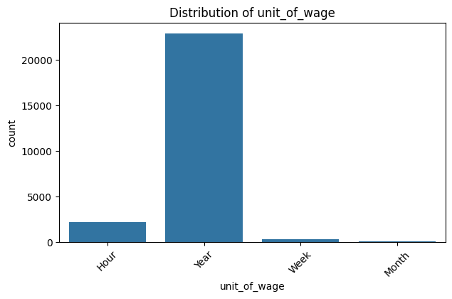

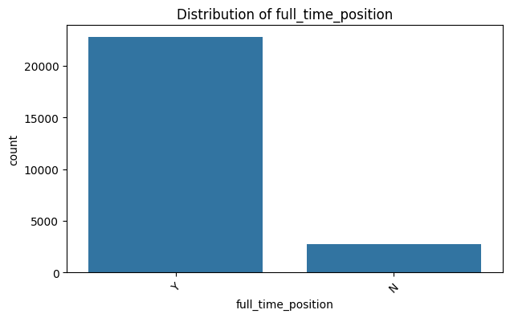

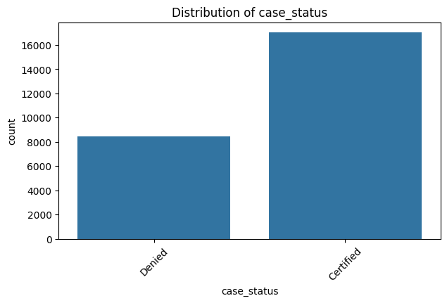

```python
# Loop through all categorical columns (except case_id)
# and plot count plots to visualize their distribution
for col in cat_cols:
    if col != "case_id":
        plt.figure(figsize=(7,4))
        sns.countplot(x=df[col])
        plt.title(f"Distribution of {col}")
        plt.xticks(rotation=45)
        plt.show()
```

**Observations (Continent Distribution)**

1. Majority of applicants are from Asia.
2. Europe and North America contribute a moderate number of applications.
3. Very few applications come from Africa, South America, and Oceania.
4. The data is highly skewed toward Asia.

**Observations (Education of Employee)**

1. Majority of applicants hold a Bachelor’s degree.
2. A large number also have a Master’s degree.
3. Fewer applicants have only High School education.
4. Doctorate holders represent the smallest group.

Overall, most applicants are highly educated (Bachelor’s or above)

**Observations (Job Experience)**

1. More applicants have prior job experience (Y) than those who do not.
2. A significant portion still has no job experience (N).
3. The distribution is slightly skewed toward experienced applicants.

**Observations (Requires Job Training)**

1. Majority of applicants do not require job training (N).
2. Only a small portion require job training (Y).
3. The distribution is highly skewed toward candidates who do not need additional training.

**Observations (Region of Employment)**

1. Most applications are from the Northeast and South regions.
2. The West region also has a significant number of applications.
3. The Midwest has comparatively fewer applications.
4. The Island region has very minimal representation.

**Observations (Unit of Wage)**

1. Majority of wages are reported on a Yearly basis.
2. A small number are reported Hourly.
3. Very few applications use Weekly or Monthly wage units.
4. The distribution is highly concentrated in the Year category.

**Observations (Full-Time Position)**

1. Majority of applications are for full-time positions (Y).
2. Only a small number are for non-full-time positions (N).
3. The distribution is highly skewed toward full-time roles.

**Observations (Case Status)**

1. Majority of visa applications are Certified.
2. Fewer applications are Denied.
3. The dataset shows class imbalance, with Certified as the dominant class

### Numerical Variables

```python
# Identify all numeric columns (integers and floats) in the DataFrame
num_cols = df.select_dtypes(include=np.number).columns
num_cols
```

```
Index(['no_of_employees', 'yr_of_estab', 'prevailing_wage'], dtype='object')
```

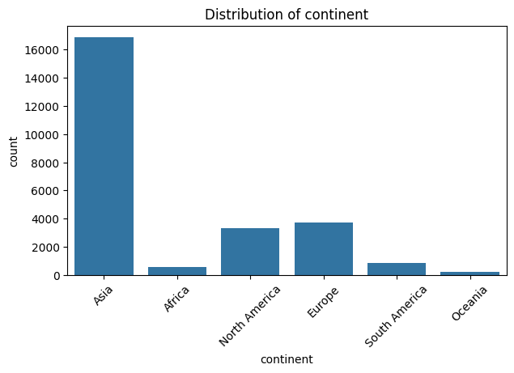

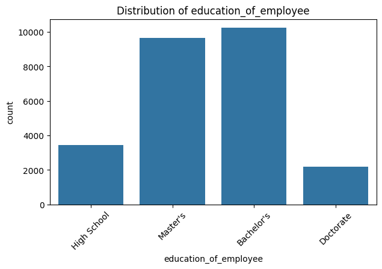

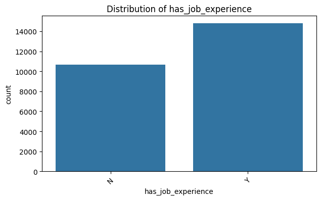

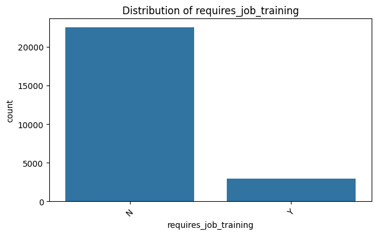

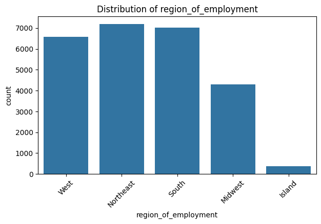

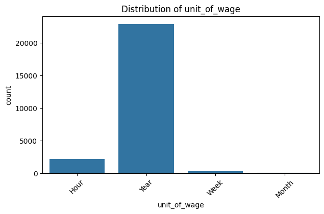

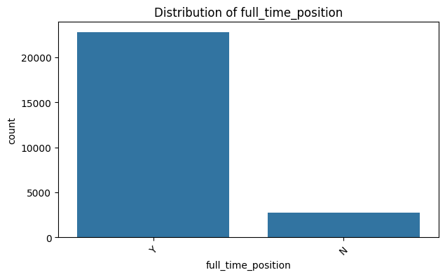

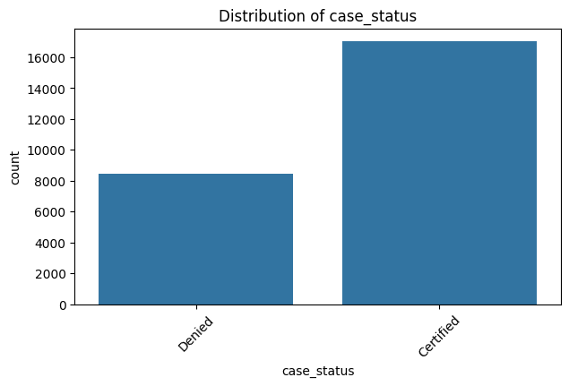

```python
# Histogram
# Iterate through each column name in the list of categorical columns
for col in cat_cols:
  # Skip the unique identifier column to avoid a messy plot with too many bars
    if col != "case_id":
        plt.figure(figsize=(7,4))
        # Create a frequency bar chart showing the count of each category
        sns.countplot(x=df[col])
        plt.title(f"Distribution of {col}")
        # Rotate x-axis labels by 45 degrees to prevent overlapping text
        plt.xticks(rotation=45)
        plt.show()
```

### Key observations from each chart

**Distribution of Continent**

1. Asia is the primary category, with over 16,000 entries.
2. Oceania has the lowest representation.
3. There is a heavy geographic skew toward Asian employees.

**Distribution of Education_of_Employee**

1. Most employees hold a Bachelor's or Master's degree (both near or above 10,000).
2. Doctorate holders are the smallest group.
3. The dataset primarily represents highly educated professionals.

**Distribution of has_job_experience**

1. More employees have job experience ("Y") than those who do not ("N").
2. Experienced workers outnumber inexperienced ones by roughly 4,000 counts.

**Distribution of requires_job_training**

1. The vast majority of positions do not require job training ("N").
2. Very few roles (approx. 3,000) include or require formal training.

**Distribution of region_of_employment**

1. Employment is highest in the Northeast, followed closely by the South and West.
2. The Island region has almost negligible representation.

**Distribution of unit_of_wage**

1. Year is the overwhelming standard for wage units (over 20,000).
2. Weekly and Monthly wage units are rarely used in this dataset.

**Distributon of full_time_position**

1. The vast majority of roles are Full-time ("Y").
2. Part-time positions ("N") make up a very small fraction of the data.

**Distributon of case_status**

1. Most cases are Certified (approx. 17,000).
2. Roughly half as many cases (approx. 8,500) are Denied compared to those certified.

## Bivariate Analysis

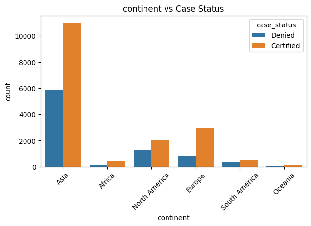

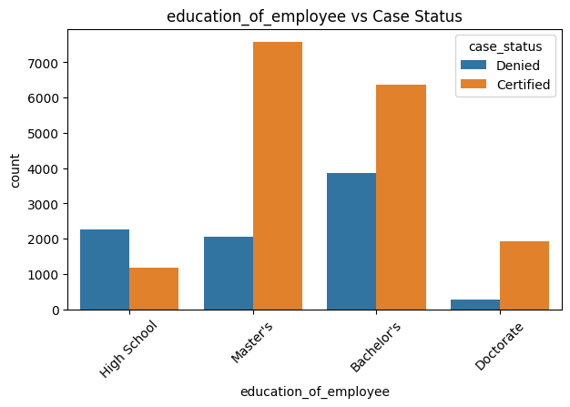

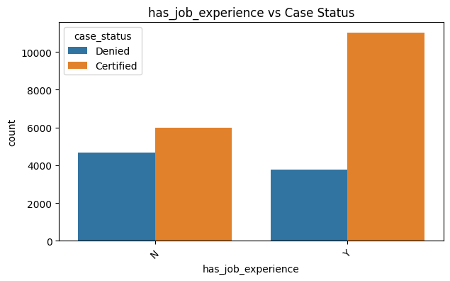

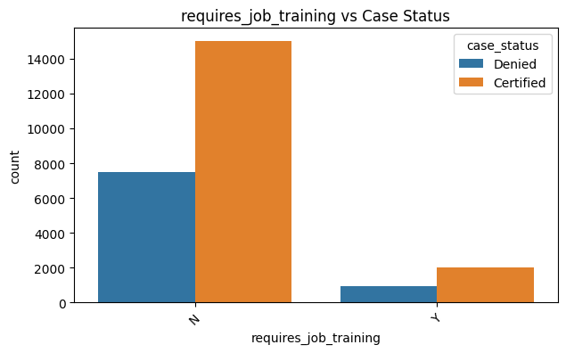

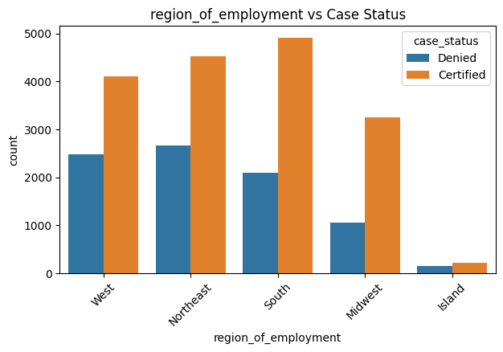

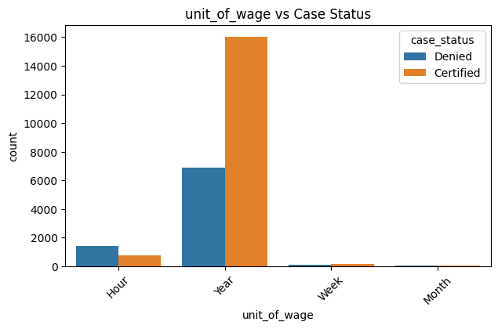

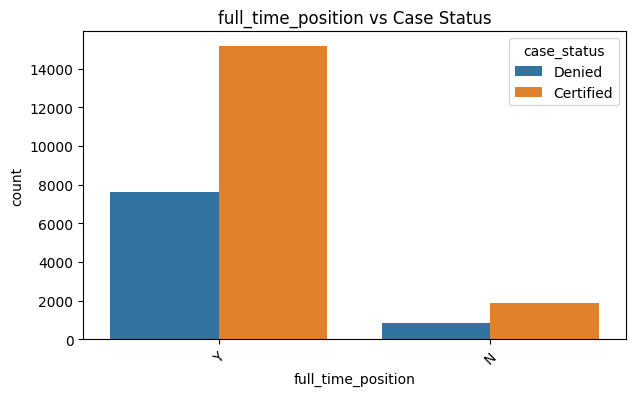

```python
#Categorical vs Target Variable
for col in cat_cols:
  # Exclude IDs and the target itself to keep the comparison meaningful
    if col not in ["case_id", "case_status"]:
        plt.figure(figsize=(7,4))
        # This line splits the count bars by 'case_status' (Certified/Denied)
        # It allows you to see the success rate within each category
        sns.countplot(x=col, hue="case_status", data=df)
        plt.xticks(rotation=45)
        plt.title(f"{col} vs Case Status")
        plt.show()
```

### Key observations from each chart

**1. Continent vs Case Status**

- **Asia** has the highest volume of both certified and denied cases.
- While Asia leads in numbers, **Europe** and **Africa** show high certification-to-denial ratios.
- Geography plays a massive role in application volume, but certification is possible across all continents.

  **3. Job Experience vs Case Status**
- Candidates with **prior job experience ("Y")** have a significantly higher likelihood of being certified.
- For those without experience ("N"), the gap between certified and denied cases is much narrower.
- Professional experience is a critical predictor of visa certification success.

**4. Job Training vs Case Status**

- **Experience Advantage:** Most certified cases are for roles that do not require formal job training.
- **Inexperienced Risk:** The ratio of certified to denied cases remains relatively similar regardless of whether training is required.

  **6. Unit of Wage vs Case Status**
- **Yearly Salaries:** Applications for **Yearly** wages have the highest certification counts and success ratios.
- **Hourly Wages:** Interestingly, **Hourly** wage applications face a much higher risk of denial, with denials often nearing or exceeding certifications.
- Salary structure is a strong indicator; yearly salaried positions are viewed more favorably.

  **7. Full-Time Position vs Case Status**
- **Full-Time Dominance:** The vast majority of certified cases are for **Full-time ("Y")** positions.
- **Part-Time:** There are very few part-time applications, and they represent a negligible portion of total certifications.

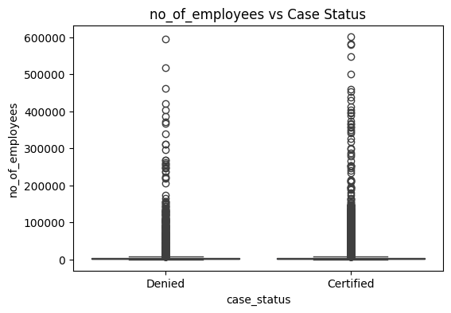

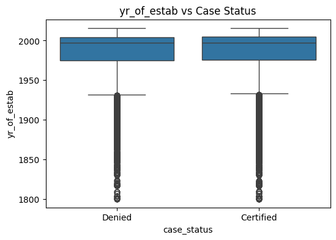

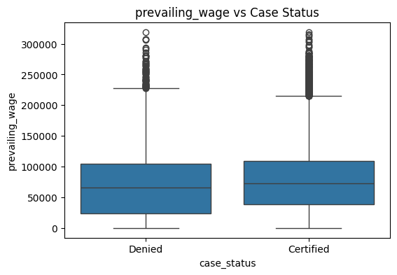

```python
#Numerical vs Target Variable
for col in num_cols:
    plt.figure(figsize=(6,4))
    sns.boxplot(x="case_status", y=col, data=df)
    plt.title(f"{col} vs Case Status")
    plt.show()
```

### Key observations for each numerical variable based on the provided box plots:

1. **No. of Employees vs Case Status**
- Most companies are small-scale businesses.
- Significant "giant" outliers exist, with some companies exceeding 600,000 employees.
- Data is heavily right-skewed, showing a huge gap between typical firms and industry giants.
1. **Year of Establishment vs Case Status**
- Most companies were founded between 1975 and 2010.
- The typical company in this dataset was established around the year 1997.
- A few "legacy" outliers date back to the 1800s.
1. **Prevailing Wage vs Case Status**
- Most salaries fall between $35,000 and $110,000.
- The middle-point wage is approximately $70,000.
- Numerous high-wage outliers exist, reaching above $300,000.

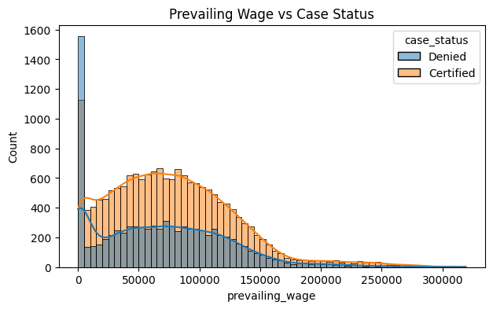

```python
#Prevailing Wage Detailed Analysis

plt.figure(figsize=(7,4))
sns.histplot(data=df, x="prevailing_wage", hue="case_status", kde=True)
plt.title("Prevailing Wage vs Case Status")
plt.show()
```

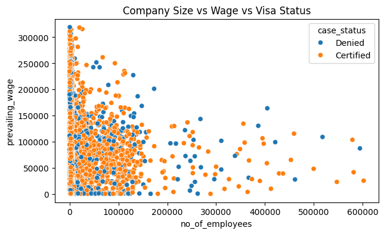

```python
#Company Size vs Case Status
plt.figure(figsize=(7,4))
sns.scatterplot(x="no_of_employees", y="prevailing_wage", hue="case_status", data=df)
plt.title("Company Size vs Wage vs Visa Status")
plt.show()
```

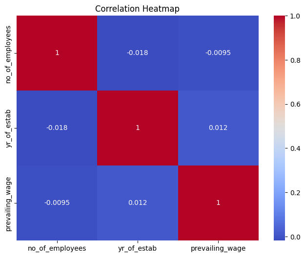

```python
#Correlation Analysis
plt.figure(figsize=(8,6))
sns.heatmap(df[num_cols].corr(), annot=True, cmap="coolwarm")
plt.title("Correlation Heatmap")
plt.show()
```

```python
#copied the datframe
df2=df.copy()
```

```python
#case_id is unique and does not help in prediction.
df.drop("case_id", axis=1, inplace=True)
```

```python
#Missing Value Detection &
#Check Missing Values
df.isnull().sum()
```

|  | 0 |
| --- | --- |
| continent | 0 |
| education_of_employee | 0 |
| has_job_experience | 0 |
| requires_job_training | 0 |
| no_of_employees | 0 |
| yr_of_estab | 0 |
| region_of_employment | 0 |
| prevailing_wage | 0 |
| unit_of_wage | 0 |
| full_time_position | 0 |
| case_status | 0 |

**dtype:** int64

No null values found

### Remove Negative Values in no_of_employees

```python
# Check how many negative values exist
df[df["no_of_employees"] < 0].shape

# Remove negative employee values
df = df[df["no_of_employees"] >= 0]

# Verify
df["no_of_employees"].min()
```

```
12
```

### Outlier Detection & Treatment

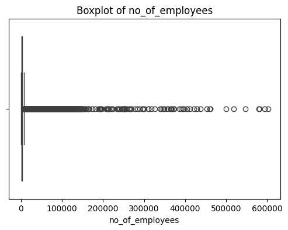

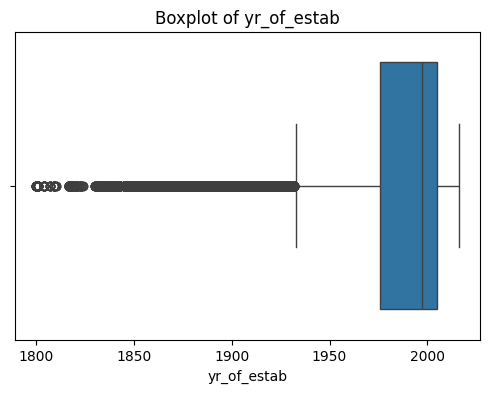

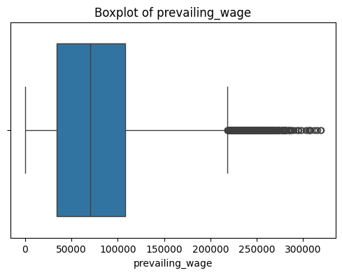

```python
#Detect Outliers Using Boxplot

# Identify all numerical columns (integers and floats) in the DataFrame
num_cols = df.select_dtypes(include=np.number).columns

# Loop through each numerical column to create individual visualizations
for col in num_cols:
    # Set the size of the plot window (width=6, height=4)
    plt.figure(figsize=(6,4))

    # Create a boxplot to visualize quartiles, median, and outliers
    sns.boxplot(x=df[col])

    # Dynamically set the title based on the column name
    plt.title(f"Boxplot of {col}")

    # Display the plot before moving to the next iteration
    plt.show()
```

### Key Observations from each boxplot

**No. of Employees**

1. The median number of employees is very low, suggesting that the majority of companies in the dataset are small-scale businesses.
2. There is a significant presence of extreme outliers on the right side, with some companies employing over $600,000$ individuals.
3. The data is heavily right-skewed, indicating a massive disparity between small firms and a few giant corporations.

**Year of Establishment**

1. The majority of companies were established relatively recently, with the interquartile range falling between approximately $1975$ and $2010$.
2. The median establishment year sits around $1997$ to $2000$.
3. There are several "legacy" outliers on the left, representing older firms founded as early as $1800$.
4. The data is left-skewed, showing that the dataset is dominated by companies founded in the last few decades.

**Prevailing Wage**

1. Most prevailing wages fall within a range of approximately $\$35,000$ to $\$110,000$.
2. The median prevailing wage is roughly $\$70,000$.
3. There are numerous outliers on the right side, with some wages exceeding $\$300,000$ per year.D
4. The distribution is right-skewed, meaning while most roles offer mid-range salaries, there are several exceptionally high-paying positions.

```python
#Outlier Treatment (Capping)
# Define a function to cap extreme values (outliers) for a specific column
def cap_outliers(col):
    # Calculate the 25th percentile (Q1) and 75th percentile (Q3)
    Q1 = df[col].quantile(0.25)
    Q3 = df[col].quantile(0.75)

    # Calculate the Interquartile Range (IQR)
    IQR = Q3 - Q1

    # Define the "fence" boundaries for outliers
    lower = Q1 - 1.5 * IQR
    upper = Q3 + 1.5 * IQR

    # If a value is higher than the upper bound, replace it with the upper bound
    df[col] = np.where(df[col] > upper, upper, df[col])

    # If a value is lower than the lower bound, replace it with the lower bound
    df[col] = np.where(df[col] < lower, lower, df[col])

# Loop through every numeric column identified earlier and apply the capping function
for col in num_cols:
    cap_outliers(col)
```

[output not shown]

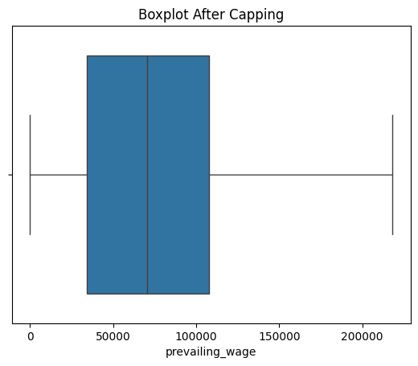

```python
# Check a specific column, e.g., 'prevailing_wage'
sns.boxplot(x=df['prevailing_wage'])
plt.title('Boxplot After Capping')
plt.show()
```

The boxplot confirms that outlier treatment was successful, as evidenced by the complete absence of data points beyond the whiskers and the containment of all values within the calculated upper and lower bounds.